# Dados CAMS x Von Donkelar

Ana Li

2025-05-28

# Desempenho dos dados de material particulado fino sobre a qualidade do ar em estudo epidemiológico no estado de Minas Gerais

### **Métodos**

**Desenho e Área de Estudo:** Estudo ecológico de séries temporais mensais em 2023, no estado de Minas Gerais.

**Base de dados:** Foram utilizadas duas bases de dados. A primeira consiste em estimativas diárias obtidas pela Copernicus Atmosphere Monitoring Service (CAMS) e a segunda possui dados mensais do satélite Von Donkelar.

**Análise de Dados:**

*Medidas de concordância*  
A concordância entre os dados diários de PM2,5 modelados do CAMS e do Von Donkelar foram investigadas por meio do teste t para amostras pareadas, do método de *Bland-Altman*. O método gráfico de *Bland-Altman* avalia a concordância entre uma medida aferida por dois métodos distintos. Diferença = $PM2.5_{von} – PM2.5_{cams}$ e Média= $\frac{PM2.5_{von} + PM2.5_{cams}}{2}$.

Nesse método, as médias são usadas como estimativas do valor verdadeiro do PM2,5 e, portanto, é possível investigar a relação dos erros com o valor verdadeiro de PM2,5.

### **Resultados**

#### Distribuição dos dados

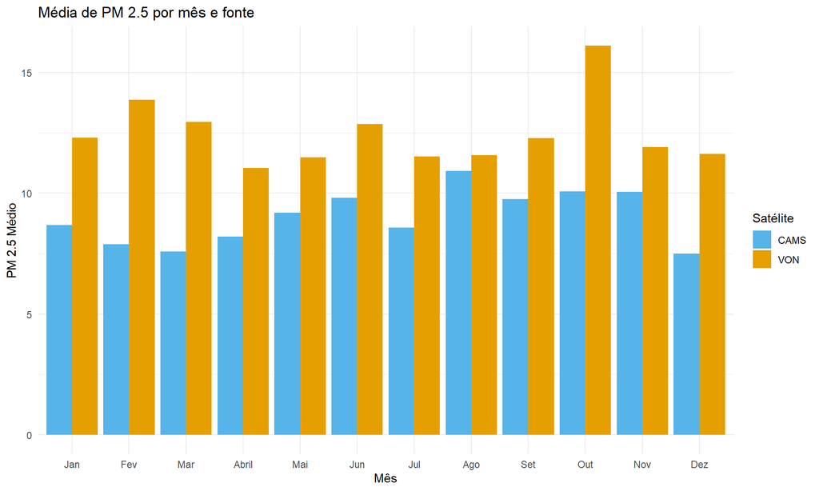

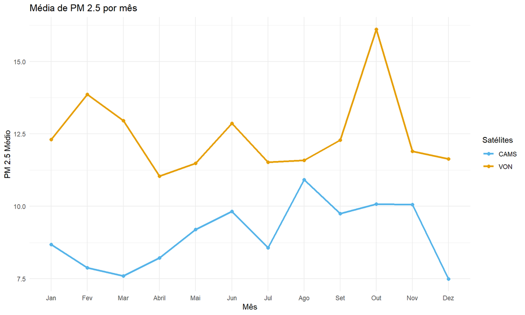

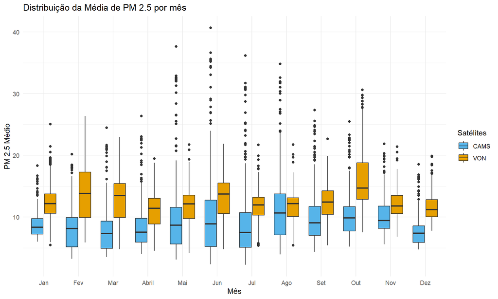

#### Comparação entre os dados da Copernicus x Von Donkelar

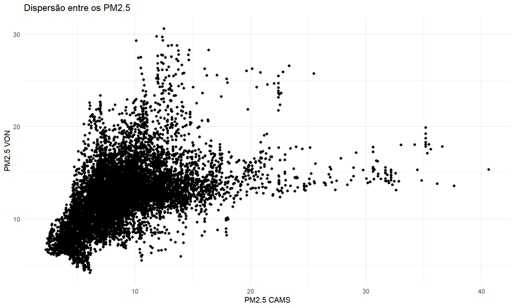

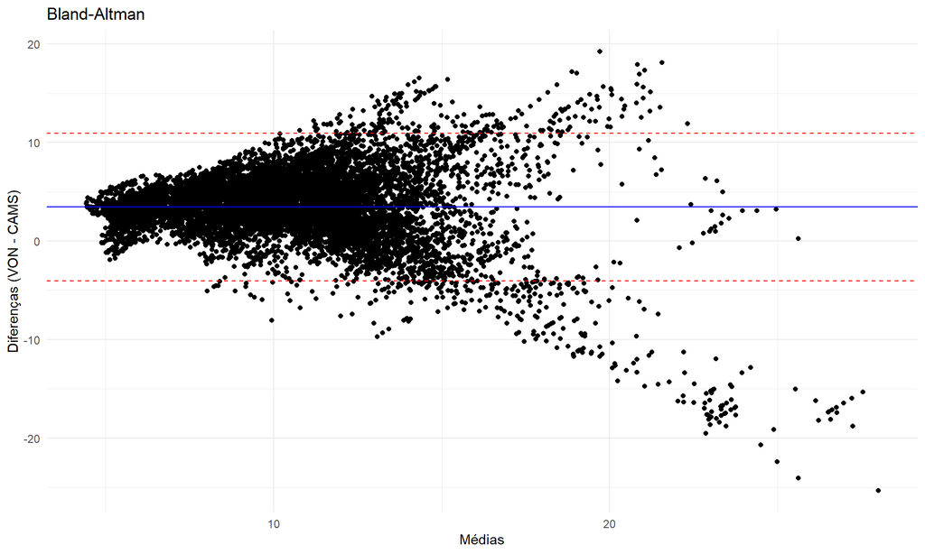

*ICC (Intraclass Correlation Coefficient)*

O ICC é usado para medir a confiabilidade ou concordância entre medidas.

A classificação da concordância a partir do ICC foi baseada na classificação de Weir (2005) dada por:

0,00 ≤ ICC ≤ 0,20 = concordância pobre,

0,20 < ICC ≤ 0,40 = concordância razoável,

0,40 < ICC ≤ 0,60 = concordância boa,

0,60 < ICC ≤ 0,80 = concordância muito boa,

0,80 < ICC ≤ 1,00 = concordância excelente.

A significância do ICC foi analisada pelo intervalo de confiança do ICC ao nível de 95% de confiança. E o valor mínimo do intervalo de confiança para o ICC deve ser maior que 0,4 para que a concordância seja considerada significativa.

```r
avaliacoes = mg_total[, c("pm2.5_mensal", "Media_PM25")]
icc1=icc(avaliacoes, model = "twoway", type = "consistency", unit = "single")
ValorICC1= round(icc1$value,2)
IC95_ICC1=c(round(icc1$lbound,3), round(icc1$ubound,3))

print(icc1)
```

```
##  Single Score Intraclass Correlation
##
##    Model: twoway
##    Type : consistency
##
##    Subjects = 10236
##      Raters = 2
##    ICC(C,1) = 0.474
##
##  F-Test, H0: r0 = 0 ; H1: r0 > 0
## F(10235,10235) = 2.8 , p = 0
##
##  95%-Confidence Interval for ICC Population Values:
##   0.459 < ICC < 0.489
```

- ICC(C,1) = 0.474 indica uma confiabilidade boa
- O teste F rejeita a hipótese nula (ICC = 0), indicando que há alguma concordância significativa

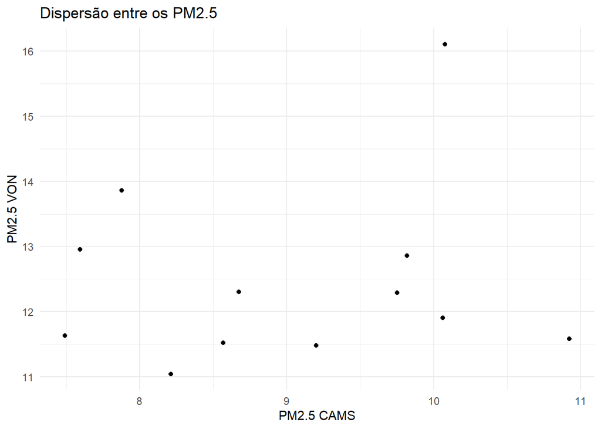

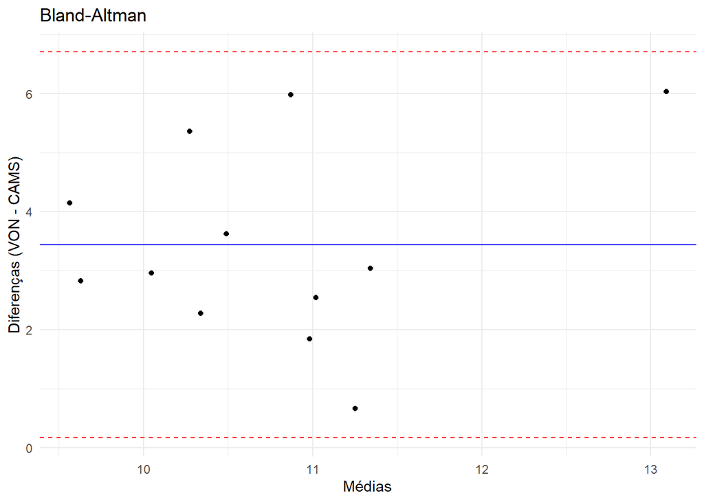

*ICC (Intraclass Correlation Coefficient)*

```r
avaliacoes2 = mg_mensal1[, c("CAMS", "VON")]
icc2=icc(avaliacoes2, model = "twoway", type = "consistency", unit = "single")
ValorICC2= round(icc2$value,2)
IC95_ICC2=c(round(icc2$lbound,3), round(icc2$ubound,3))

print(icc2)
```

```
##  Single Score Intraclass Correlation
##
##    Model: twoway
##    Type : consistency
##
##    Subjects = 12
##      Raters = 2
##    ICC(C,1) = 0.126
##
##  F-Test, H0: r0 = 0 ; H1: r0 > 0
##    F(11,11) = 1.29 , p = 0.341
##
##  95%-Confidence Interval for ICC Population Values:
##   -0.459 < ICC < 0.635
```

- ICC(C,1) = 0.126 indica uma confiabilidade pobre
- p = 0.341 não significativo (p > 0.05): Não há evidências para rejeitar a hipótese nula (ICC = 0).
- O tamanho amostral (12) é muito pequeno

### **Mapa dos PM2.5 do estado do mg**

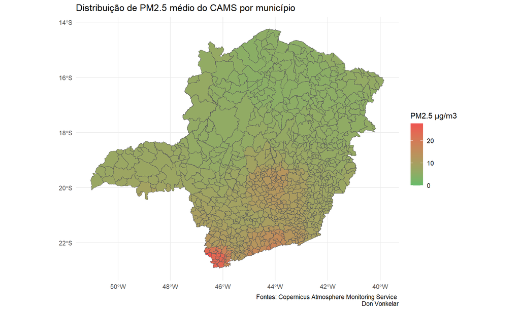

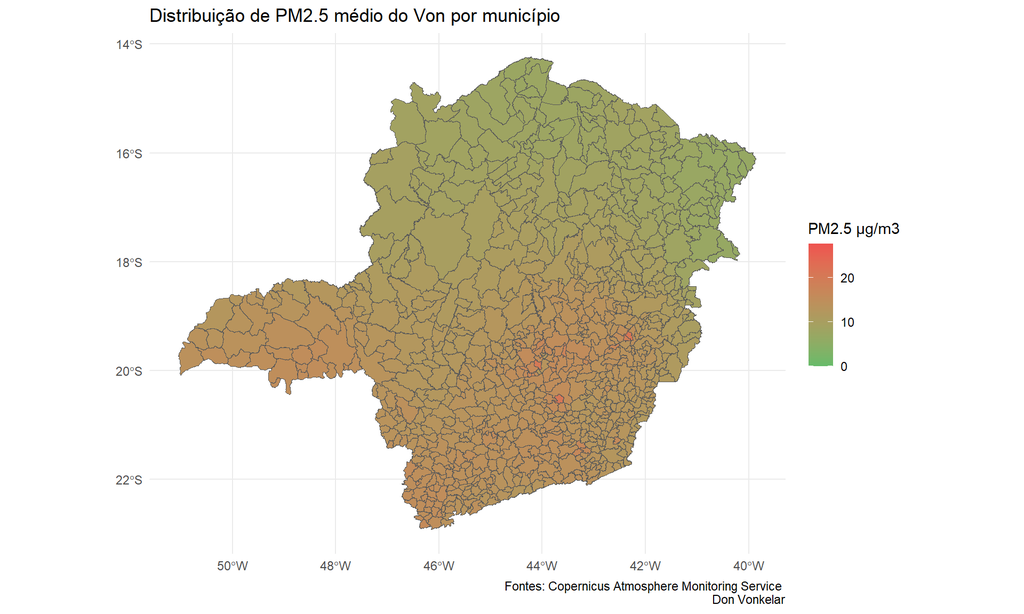

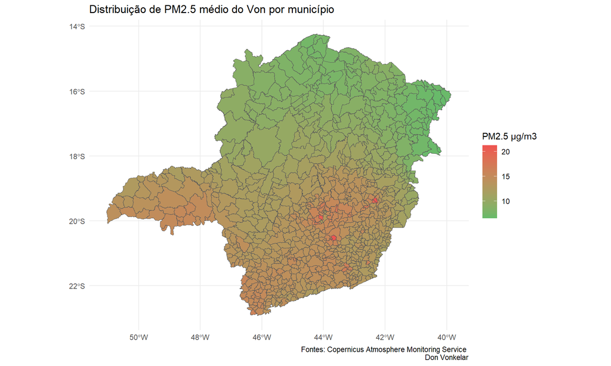

Percebemos que a o PM2.5 captado pelos dois satélites é maior na parte inferior do estado de Minas Gerais

### Teste t

O teste t pareado foi utilizado para avaliar diferenças entre os métodos de medição quanto ao viés sistemático.

```r
# teste t mensal (1)
t.test(mg_mensal1$VON, mg_mensal1$CAMS, paired = TRUE)
```

```
##
##  Paired t-test
##
## data:  mg_mensal1$VON and mg_mensal1$CAMS
## t = 7.15, df = 11, p-value = 1.869e-05
## alternative hypothesis: true mean difference is not equal to 0
## 95 percent confidence interval:
##  2.381953 4.500610
## sample estimates:
## mean difference
##        3.441282
```

```r
# teste t municipios (2)
t.test(mg_total$Media_PM25, mg_total$pm2.5_mensal, paired = TRUE)
```

```
##
##  Paired t-test
##
## data:  mg_total$Media_PM25 and mg_total$pm2.5_mensal
## t = 91.298, df = 10235, p-value < 2.2e-16
## alternative hypothesis: true mean difference is not equal to 0
## 95 percent confidence interval:
##  3.367396 3.515167
## sample estimates:
## mean difference
##        3.441282
```

### Referências

WEIR, J.P. (2005) Quantifying test-retest reliability using the intraclass correlation coefficient and the SEM. J StrengthCond Res. 19(1):231-40.

https://atmosphere.copernicus.eu/charts/packages/cams/

https://sites.wustl.edu/acag/datasets/surface-pm2-5/#V6.GL.02.03